# Geo+Python: A Shallow Dive into GIS Development

### Enock Seth Nyamador [@enock4seth](http://twitter.com/enock4seth/)

#### Open Source evangelist

CC-BY-SA 4.0

# !

### Neither GIS nor Python expert

### Convincing enough

### Lifegaurd is on leave

# What?

### - GIS Basics

### - OSGeo, QGIS, PyQGIS

### - OpenStreetMap, etc

### - Py projects; GeoNode, etc

# Why?

#### [Everything that happens, happens somewhere](https://www.youtube.com/watch?v=Mkge03NJhfU)

#### PS: Snakes undertand geography.

[figure not shown]

# GIS

- Geographic Information Systems
- hardware, software and data capturing, managing, analysing and displaying spatial data
- use methods for understanding, interpreting, and visualising relationships and patterns of geospatial data

[figure not shown]

# Data Types

### - Vector

### - Raster

# Vector

### GeoPackage (gpkg), GeoJSON, PostGIS

- SHPs

[figure not shown]

# Raster

### Geotiffs, DEM, Orthophotos, etc

[figure not shown]

# Cordinate Reference System

[figure not shown]

# Geospatial development tasks - Analysis

### - Disaster Risk Management; Accra Floods

### - How many hours do we waste in moving from Madina to Accra Central in a trotro?

### - Accessbility, connectivity, etc

# Data Sources

## What kinds of GeoSpatial Data is available?

- It depends!

### Government

- Local
- State
- Federal

### Private

- Energy
- Technology
- Transportation

### The Crowd

# OpenStreetMap

- Online, Offline, Open Data -- XML
- osm.org
- Map the world from scratch
- Save lives
- Used by FB, Uber, Humanitarian Response and preparedness [Earthquake, flood, tsunami, etc] (OCHA, Red Cross, UNICEF), Mapbox, etc
- Try it: [OsmAnd](https://osmand.net) OR [MAPS.ME](https://maps.me/en/download/)

[figure not shown]

# Features (POIs) in OpenStreetMap

- Attributes are key-value pairs
- [Map Features](https://wiki.openstreetmap.org/wiki/Map_Features)

[figure not shown]

```
<?xml version="1.0" encoding="UTF-8"?>
<osm version="0.6" generator="CGImap 0.7.5 (21114 thorn-02.openstreetmap.org)" copyright="OpenStreetMap and contributors" attribution="http://www.openstreetmap.org/copyright" license="http://opendatacommons.org/licenses/odbl/1-0/">
 <way id="308668766" visible="true" version="14" changeset="72300285" timestamp="2019-07-16T11:27:32Z" user="Michael008" uid="7666560">
  ........
  <tag k="addr:city" v="Accra"/>
  <tag k="amenity" v="university"/>
  <tag k="contact:twitter" v="https://twitter.com/UnivofGhana"/>
  <tag k="contact:website" v="http://ug.edu.gh/"/>
  <tag k="description" v="University of Ghana is the first and largest universitiy and tertiary institution in Ghana."/>
  <tag k="name" v="University of Ghana"/>
  <tag k="opening_hours" v="24/7"/>
  <tag k="operator:type" v="public"/>
  <tag k="project:oif-dfen_carteinnov" v="yes"/>
  <tag k="short_name" v="UG, Legon"/>
  <tag k="source" v="local_knowledge;oif-dfen_carteinnov"/>
  <tag k="source:geometry" v="Bing"/>
  <tag k="start_date" v="1948"/>
  <tag k="wikidata" v="Q2303765"/>
  <tag k="wikipedia" v="en:University of Ghana"/>
 </way>
</osm>
```

# Overpass API

#### - overpass-turbo.eu/

```python
import requests

overpass_url = "http://overpass-api.de/api/interpreter"
overpass_query = """
    [out:json];
    area["ISO3166-1"="GH"][admin_level=2];
    (
    node["amenity"="school"](area);
    );
    out count;"""
response = requests.get(overpass_url, params={'data': overpass_query})
response.json()
```

```
{'version': 0.6,
 'generator': 'Overpass API 0.7.55.7 8b86ff77',
 'osm3s': {'timestamp_osm_base': '2019-08-09T01:39:03Z',
  'timestamp_areas_base': '2019-08-09T00:37:02Z',
  'copyright': 'The data included in this document is from www.openstreetmap.org. The data is made available under ODbL.'},
 'elements': [{'type': 'count',
   'id': 0,
   'tags': {'nodes': '1425',
    'ways': '0',
    'relations': '0',
    'areas': '0',
    'total': '1425'}}]}
```

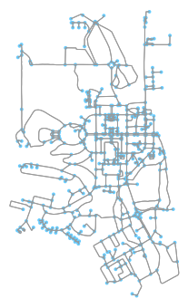

```python
import osmnx as ox
import matplotlib.pyplot as plt
%matplotlib inline

# Specify the name that is used to seach for the data
place_name = "University of Ghana, Accra, Ghana"

# Fetch OSM street network from the location
graph = ox.graph_from_place(place_name)
type(graph)

# Plot the streets
fig, ax = ox.plot_graph(graph)
```

# OSM in Africa

### TL;DR

- OSM [Togo, Benin, Côte d'Ivoire , Burkina Faso, Mali, Guinea, Uganda, etc]
- [Open Cities Accra](https://opencitiesproject.org/) - OpenDRI
- [Map Kibera](http://mapkibera.org/)
- [Ramani Huria](https://wiki.openstreetmap.org/wiki/Dar_es_Salaam/Ramani_Huria) - HOTOSM
- [Ebola Response](https://wiki.openstreetmap.org/wiki/2014_West_Africa_Ebola_Response)

#### - [2019.stateofthemap.africa](https://2019.stateofthemap.africa/) | 22-24 November 2019 | Grand-Bassam, Côte d'Ivoire

### Ghana

- [Open Cities Accra](https://opencitiesproject.org/accra/)
- AccraMobile3
- Larabanga Mapping Initiative
- [OpenStreetMap Ghana](https://osmghana.org)
- Data Reuse: [trotro.app](https://www.trotro.app/)
- github.com/trufi-association/trufi-app | GPL 3.0
- github.com/grote/osm2gtfs | GPL 3.0

[figure not shown]

# GIS Applications

## FOSS4G: OSGeo - QGIS, GDAL, GRASS, etc

- Your Open Source geospatial compass

[figure not shown]

## $$$: ESRI - ArcGIS

# QGIS

- the user friendly Open Source Geographic Information System
- [qgis.org](https://qgis.org/en/site/)
- Python plugins

[figure not shown]

Tweet by [@klaskarlsson](https://twitter.com/klaskarlsson/status/1159514845127028738?s=09)

[figure not shown]

# GeoNode

- A web-based application and platform for developing geospatial information systems (GIS) and for deploying spatial data infrastructures (SDI).
- Django
- http://geonode.org/

[figure not shown]

### Contributors

- World Bank
- GeoSoulutions
- Terranodo
- Boundless
- .......

# Some libraries

### Reading and writing geospatial data

- GDAL/OGR

### Dealing with Projections

- pyproj

### Analysing and manipulating geospatial data

- shapely

### Visualalizing geospatial data

- mapnik

### - GIS is fun !

### - There are many python geospatial libraries

### - Python loves Geo and vice versa

### - Geo Data Science

### - Taking over !

### - Go out, get XYZ. Create accessible Open Data :)

### - No rocket science

# Community of Practice

### - *cons, Wikimania, PyCon, SOTM, FOSS4G, etc...

### - Linux User Groups - [Linux Accra](https://linuxaccra.org), etc

[figure not shown]

## [This slide intentionally left blank](https://this-page-intentionally-left-blank.org/)

# Geo+Python: A Shallow Dive into GIS Development

### Enock Seth Nyamador [@enock4seth](http://twitter.com/enock4seth/)

- open [at] enockseth [dot] co
- open.enockseth.co
- Slides @ open.enockseth.co/slides/geo+python/

### Resources

- [Data Science with OpenStreetMap and Python](https://github.com/njanakiev/osm-data-science)
- [Introduction to Python GIS](https://automating-gis-processes.github.io/CSC/notebooks/L3/retrieve_osm_data.html)
- [Introduction to Geospatial Data with Python](https://github.com/SocialDataSci/Geospatial_Data_with_Python)
- [Workshop QGIS Python GeoPython 2018](https://giswiki.hsr.ch/Workshop_QGIS_Python_GeoPython_2018)
- [QGIS Tutorials and Tips](https://www.qgistutorials.com/en/)
- [PyQGIS 101](https://anitagraser.com/pyqgis-101-introduction-to-qgis-python-programming-for-non-programmers/)